# PSY 8712 Week 8 Project

Michael Hazboun

2024-03-17

I finished this and noticed that you wanted 1 to 2 sentence explanations for why we chose to do what we did. I used much more than that to start, so for the full version [go here](https://docs.google.com/document/d/1hO2VGmAc63v3pOvx9EORhB7ONFAcy36gHcczCAgYwTc/edit?usp=sharing)

**Reproducible Image and Online Resources:**

An image of this project as of *2024-03-17* can be accessed by [clicking this link](https://mybinder.org/v2/gh/MichaelHazboun/psy8712-week8/HEAD?urlpath=rstudio).

An interactive web app is available by [clicking this link instead](https://michaelhazboun.shinyapps.io/shiny_week8/).

**Script Settings and Resources**

```r
setwd(dirname(rstudioapi::getActiveDocumentContext()$path))
library(tidyverse)
```

**Data Import and Cleaning**

Imported and cleaned the data: factorized gender, reverse coded q5 and made two new variables, the mean for Q1:6 and the mean for Q8:10. I didn’t change anything else because I didn’t want to make any assumptions on this dataset based off of our previous homeworks (we might be in a different world where q6 wasn’t used as a manipulation check…)

```r
week8_tbl <- read_csv("../data/week3.csv", col_names = T) %>%
  mutate(gender = factor(gender, levels=c("M","F"), labels = c("Male","Female"))) %>%
  mutate(q5=6-q5)%>%
  rowwise()  %>%
  mutate(mq1_6= mean(c(q1,q2,q3,q4,q5,q6), na.rm = T)) %>%  # I tried using q1:q6, but when I was checking the responses, it wasn't right, it was giving me different answers for each line, but not the right one..
  mutate(mq8_10= mean(c(q8,q9,q10), na.rm = T))
```

**Visualization**

I hid the code using echo, hid the message using message and made a plot using ggplot, geom_point and geom_smooth. I used these methods because they were the easiest and most intuitive to me.

| q1 | q2 | q3 | q4 | q5 | q6 |
| --- | --- | --- | --- | --- | --- |
| 5 | 4 | 4 | 1 | 2 | 1 |
| 2 | 4 | 3 | 1 | 3 | 1 |
| 5 | 5 | 2 | 1 | 5 | 1 |
| 4 | 3 | 4 | 2 | 4 | 1 |
| 3 | 1 | 3 | 5 | 2 | 1 |
| 4 | 3 | 2 | 3 | 3 | 1 |
| 2 | 4 | 1 | 3 | 1 | 1 |
| 4 | 2 | 5 | 1 | 1 | 1 |
| 2 | 5 | 3 | 4 | 2 | 1 |
| 3 | 4 | 2 | 4 | 5 | 1 |

[output cut: 39 more lines]

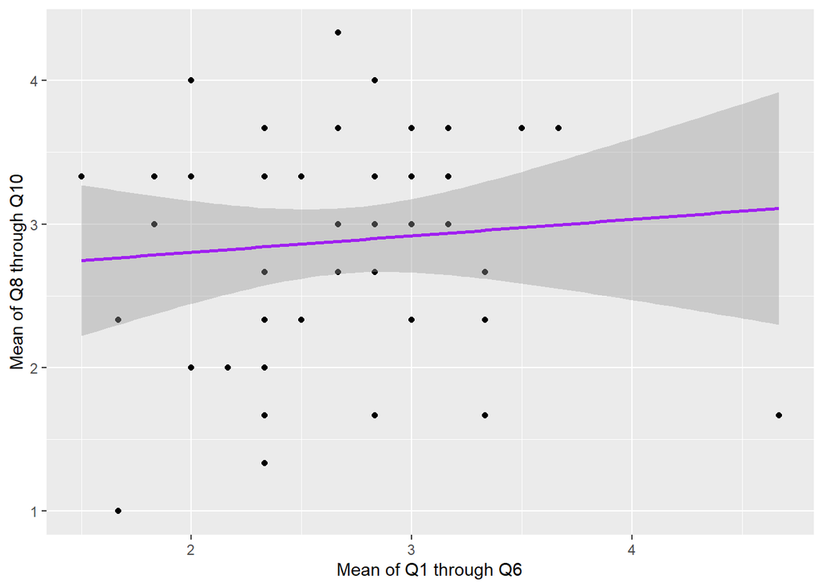

**Analysis**

I calculated the correlation, pulled the pvalue and correlation out of the output and rounded both values with round() and removed the leading zeros with str_remove. This was the easiest way I could think of to remove the leading zeros. (Also hid the code using echo=F)

```
##
##  Pearson's product-moment correlation
##
## data:  week8_tbl$mq1_6 and week8_tbl$mq8_10
## t = 0.58309, df = 47, p-value = 0.5626
## alternative hypothesis: true correlation is not equal to 0
## 95 percent confidence interval:
##  -0.2012466  0.3574248
## sample estimates:
##        cor
## 0.08474575
```

I observed a correlation of .08 between the mean of questions one through six and the mean of question eight through ten. The associated P values was rough .56, assuming an alpha of 0.05, we fail to reject the null hypothesis, that the correlation between the means is actually 0, because the p value is larger than our alpha.

**Data Export**

I used saveRDS to same the file in the shiny folder and only included relevant variables.

```r
week8_tbl %>%
  select(timeEnd,gender,mq1_6,mq8_10) %>%
  saveRDS("../shiny_week8/data.rds")
```